# R Notebook

```r
library(tidyverse)
library(GGally)
library(ggfortify)
library(modelr)
```

```r
wine_quality_red <- read_csv("Weekend Homework/wine_quality_red.csv")
wine_quality_white <- read_csv("Weekend Homework/wine_quality_white.csv")
wine_quality_red
```

| wine_id | fixed_acidity | volatile_acidity | citric_acid | residual_sugar | chlorides | free_sulfur_dioxide | total_sulfur_dioxide | density | p_h | sulphates | alcohol | quality | region |
| --- | --- | --- | --- | --- | --- | --- | --- | --- | --- | --- | --- | --- | --- |
| 1 | 7.4 | 0.700 | 0.00 | 1.90 | 0.076 | 11.0 | 34 | 0.99780 | 3.51 | 0.56 | 9.4 | 4.66 | Australia |
| 2 | 7.8 | 0.880 | 0.00 | 2.60 | 0.098 | 25.0 | 67 | 0.99680 | 3.20 | 0.68 | 9.8 | 4.82 | Spain |
| 3 | 7.8 | 0.760 | 0.04 | 2.30 | 0.092 | 15.0 | 54 | 0.99700 | 3.26 | 0.65 | 9.8 | 4.91 | Spain |
| 4 | 11.2 | 0.280 | 0.56 | 1.90 | 0.075 | 17.0 | 60 | 0.99800 | 3.16 | 0.58 | 9.8 | 5.96 | Australia |
| 5 | 7.4 | 0.700 | 0.00 | 1.90 | 0.076 | 11.0 | 34 | 0.99780 | 3.51 | 0.56 | 9.4 | 5.42 | Italy |
| 6 | 7.4 | 0.660 | 0.00 | 1.80 | 0.075 | 13.0 | 40 | 0.99780 | 3.51 | 0.56 | 9.4 | 4.78 | Italy |
| 7 | 7.9 | 0.600 | 0.06 | 1.60 | 0.069 | 15.0 | 59 | 0.99640 | 3.30 | 0.46 | 9.4 | 5.09 | USA |
| 8 | 7.3 | 0.650 | 0.00 | 1.20 | 0.065 | 15.0 | 21 | 0.99460 | 3.39 | 0.47 | 10.0 | 6.78 | Italy |
| 9 | 7.8 | 0.580 | 0.02 | 2.00 | 0.073 | 9.0 | 18 | 0.99680 | 3.36 | 0.57 | 9.5 | 7.10 | USA |
| 10 | 7.5 | 0.500 | 0.36 | 6.10 | 0.071 | 17.0 | 102 | 0.99780 | 3.35 | 0.80 | 10.5 | 4.78 | Australia |

[output cut: 990 more lines]

```r
wine_quality_white
```

| wine_id | fixed_acidity | volatile_acidity | citric_acid | residual_sugar | chlorides | free_sulfur_dioxide | total_sulfur_dioxide | density | p_h | sulphates | alcohol | quality | region |
| --- | --- | --- | --- | --- | --- | --- | --- | --- | --- | --- | --- | --- | --- |
| 1 | 7.0 | 0.270 | 0.36 | 20.70 | 0.045 | 45.0 | 170.0 | 1.00100 | 3.00 | 0.45 | 8.8 | 5.92 | Australia |
| 2 | 6.3 | 0.300 | 0.34 | 1.60 | 0.049 | 14.0 | 132.0 | 0.99400 | 3.30 | 0.49 | 9.5 | 6.06 | Australia |
| 3 | 8.1 | 0.280 | 0.40 | 6.90 | 0.050 | 30.0 | 97.0 | 0.99510 | 3.26 | 0.44 | 10.1 | 6.25 | Spain |
| 4 | 7.2 | 0.230 | 0.32 | 8.50 | 0.058 | 47.0 | 186.0 | 0.99560 | 3.19 | 0.40 | 9.9 | 6.38 | Spain |
| 5 | 7.2 | 0.230 | 0.32 | 8.50 | 0.058 | 47.0 | 186.0 | 0.99560 | 3.19 | 0.40 | 9.9 | 6.35 | USA |
| 6 | 8.1 | 0.280 | 0.40 | 6.90 | 0.050 | 30.0 | 97.0 | 0.99510 | 3.26 | 0.44 | 10.1 | 5.82 | Italy |
| 7 | 6.2 | 0.320 | 0.16 | 7.00 | 0.045 | 30.0 | 136.0 | 0.99490 | 3.18 | 0.47 | 9.6 | 5.53 | Australia |
| 8 | 7.0 | 0.270 | 0.36 | 20.70 | 0.045 | 45.0 | 170.0 | 1.00100 | 3.00 | 0.45 | 8.8 | 6.17 | Australia |
| 9 | 6.3 | 0.300 | 0.34 | 1.60 | 0.049 | 14.0 | 132.0 | 0.99400 | 3.30 | 0.49 | 9.5 | 6.08 | Italy |
| 10 | 8.1 | 0.220 | 0.43 | 1.50 | 0.044 | 28.0 | 129.0 | 0.99380 | 3.22 | 0.45 | 11.0 | 5.86 | USA |

[output cut: 990 more lines]

Traits which make a good wine: acidity - high acidity, sharper the taste of the wine, feel lighter bodied tannin - phenolic compounds in wine, bitter taste, higher in red wines alcohol - higher alcohol bolder taste, low alcohol wines - feel lighter sweetness - refers to levels of residual sugar (sweet wines have higher residual sugar) - all traits must be balanced.

variables: outcome = quality

vif - various inflation factor

input =

1 - fixed acidity: most acids involved with wine are fixed or nonvolatile (do not evaporate readily)

2 - volatile acidity: the amount of acetic acid in wine, hight levels can cause vinegar taste

3 - citric acid: small amount in wines, can add ‘freshness’ and flavour

4 - residual sugar: the amount of sugar residual after fermentation, wines with less than 1 gram/liter and greater than 45 grams/liter are sweet

5 - chlorides: “salts” in the wine

6 - free sulfur dioxide: the free form of SO2 exists in equilibrium between molecular SO2 (as a dissolved gas) and bisulfite ion; it prevents microbial growth and the oxidation of wine

7 - total sulfur dioxide: total free and bound forms of S02; in low concentrations undetectable but free SO2 concentrations over 50 ppm, can affect smell and taste

8 - density: the density of wine is close to that of water depending on the percent alcohol and sugar content

9 - pH: describes how acidic or basic a wine is, most wines are between 3-4 on the pH scale

10 - sulphates: a wine additive which can contribute to sulfur dioxide gas (S02) levels, wich acts as an antimicrobial and antioxidant

11 - alcohol: the percent alcohol content of the wine

```r
wine_quality_red_type <- wine_quality_red %>%
  mutate(wine_id = str_c("r", wine_id, sep = "_"),
         colour = "red",
         .after = wine_id
         )

wine_quality_white_type <- wine_quality_white %>%
  mutate(wine_id = str_c("w", wine_id, sep = "_"),
         colour = "white",
         .after = wine_id
         )
```

```r
wine_quality_combined <- rbind(wine_quality_red_type, wine_quality_white_type) %>%
  select(-wine_id)
```

```r
wine_quality_combined
```

| colour | fixed_acidity | volatile_acidity | citric_acid | residual_sugar | chlorides | free_sulfur_dioxide | total_sulfur_dioxide | density | p_h | sulphates | alcohol | quality | region |
| --- | --- | --- | --- | --- | --- | --- | --- | --- | --- | --- | --- | --- | --- |
| red | 7.4 | 0.700 | 0.00 | 1.90 | 0.076 | 11.0 | 34 | 0.99780 | 3.51 | 0.56 | 9.4 | 4.66 | Australia |
| red | 7.8 | 0.880 | 0.00 | 2.60 | 0.098 | 25.0 | 67 | 0.99680 | 3.20 | 0.68 | 9.8 | 4.82 | Spain |
| red | 7.8 | 0.760 | 0.04 | 2.30 | 0.092 | 15.0 | 54 | 0.99700 | 3.26 | 0.65 | 9.8 | 4.91 | Spain |
| red | 11.2 | 0.280 | 0.56 | 1.90 | 0.075 | 17.0 | 60 | 0.99800 | 3.16 | 0.58 | 9.8 | 5.96 | Australia |
| red | 7.4 | 0.700 | 0.00 | 1.90 | 0.076 | 11.0 | 34 | 0.99780 | 3.51 | 0.56 | 9.4 | 5.42 | Italy |
| red | 7.4 | 0.660 | 0.00 | 1.80 | 0.075 | 13.0 | 40 | 0.99780 | 3.51 | 0.56 | 9.4 | 4.78 | Italy |
| red | 7.9 | 0.600 | 0.06 | 1.60 | 0.069 | 15.0 | 59 | 0.99640 | 3.30 | 0.46 | 9.4 | 5.09 | USA |
| red | 7.3 | 0.650 | 0.00 | 1.20 | 0.065 | 15.0 | 21 | 0.99460 | 3.39 | 0.47 | 10.0 | 6.78 | Italy |
| red | 7.8 | 0.580 | 0.02 | 2.00 | 0.073 | 9.0 | 18 | 0.99680 | 3.36 | 0.57 | 9.5 | 7.10 | USA |
| red | 7.5 | 0.500 | 0.36 | 6.10 | 0.071 | 17.0 | 102 | 0.99780 | 3.35 | 0.80 | 10.5 | 4.78 | Australia |

[output cut: 990 more lines]

```r
head(wine_quality_combined)
```

| colour | fixed_acidity | volatile_acidity | citric_acid | residual_sugar | chlorides | free_sulfur_dioxide | total_sulfur_dioxide | density | p_h | sulphates | alcohol | quality | region |
| --- | --- | --- | --- | --- | --- | --- | --- | --- | --- | --- | --- | --- | --- |
| red | 7.4 | 0.70 | 0.00 | 1.9 | 0.076 | 11 | 34 | 0.9978 | 3.51 | 0.56 | 9.4 | 4.66 | Australia |
| red | 7.8 | 0.88 | 0.00 | 2.6 | 0.098 | 25 | 67 | 0.9968 | 3.20 | 0.68 | 9.8 | 4.82 | Spain |
| red | 7.8 | 0.76 | 0.04 | 2.3 | 0.092 | 15 | 54 | 0.9970 | 3.26 | 0.65 | 9.8 | 4.91 | Spain |
| red | 11.2 | 0.28 | 0.56 | 1.9 | 0.075 | 17 | 60 | 0.9980 | 3.16 | 0.58 | 9.8 | 5.96 | Australia |
| red | 7.4 | 0.70 | 0.00 | 1.9 | 0.076 | 11 | 34 | 0.9978 | 3.51 | 0.56 | 9.4 | 5.42 | Italy |
| red | 7.4 | 0.66 | 0.00 | 1.8 | 0.075 | 13 | 40 | 0.9978 | 3.51 | 0.56 | 9.4 | 4.78 | Italy |

```r
summary(wine_quality_combined) # no NA's in the data...
```

```
    colour          fixed_acidity    volatile_acidity  citric_acid     residual_sugar     chlorides
 Length:6497        Min.   : 3.800   Min.   :0.0800   Min.   :0.0000   Min.   : 0.600   Min.   :0.00900
 Class :character   1st Qu.: 6.400   1st Qu.:0.2300   1st Qu.:0.2500   1st Qu.: 1.800   1st Qu.:0.03800
 Mode  :character   Median : 7.000   Median :0.2900   Median :0.3100   Median : 3.000   Median :0.04700
                    Mean   : 7.215   Mean   :0.3397   Mean   :0.3186   Mean   : 5.443   Mean   :0.05603
                    3rd Qu.: 7.700   3rd Qu.:0.4000   3rd Qu.:0.3900   3rd Qu.: 8.100   3rd Qu.:0.06500
                    Max.   :15.900   Max.   :1.5800   Max.   :1.6600   Max.   :65.800   Max.   :0.61100
 free_sulfur_dioxide total_sulfur_dioxide    density            p_h          sulphates         alcohol
 Min.   :  1.00      Min.   :  6.0        Min.   :0.9871   Min.   :2.720   Min.   :0.2200   Min.   : 8.00
 1st Qu.: 17.00      1st Qu.: 77.0        1st Qu.:0.9923   1st Qu.:3.110   1st Qu.:0.4300   1st Qu.: 9.50
 Median : 29.00      Median :118.0        Median :0.9949   Median :3.210   Median :0.5100   Median :10.30
 Mean   : 30.53      Mean   :115.7        Mean   :0.9947   Mean   :3.219   Mean   :0.5313   Mean   :10.49
 3rd Qu.: 41.00      3rd Qu.:156.0        3rd Qu.:0.9970   3rd Qu.:3.320   3rd Qu.:0.6000   3rd Qu.:11.30
 Max.   :289.00      Max.   :440.0        Max.   :1.0390   Max.   :4.010   Max.   :2.0000   Max.   :14.90
    quality         region
 Min.   :2.530   Length:6497
 1st Qu.:5.150   Class :character
 Median :5.860   Mode  :character
 Mean   :5.844
 3rd Qu.:6.400
 Max.   :9.440
```

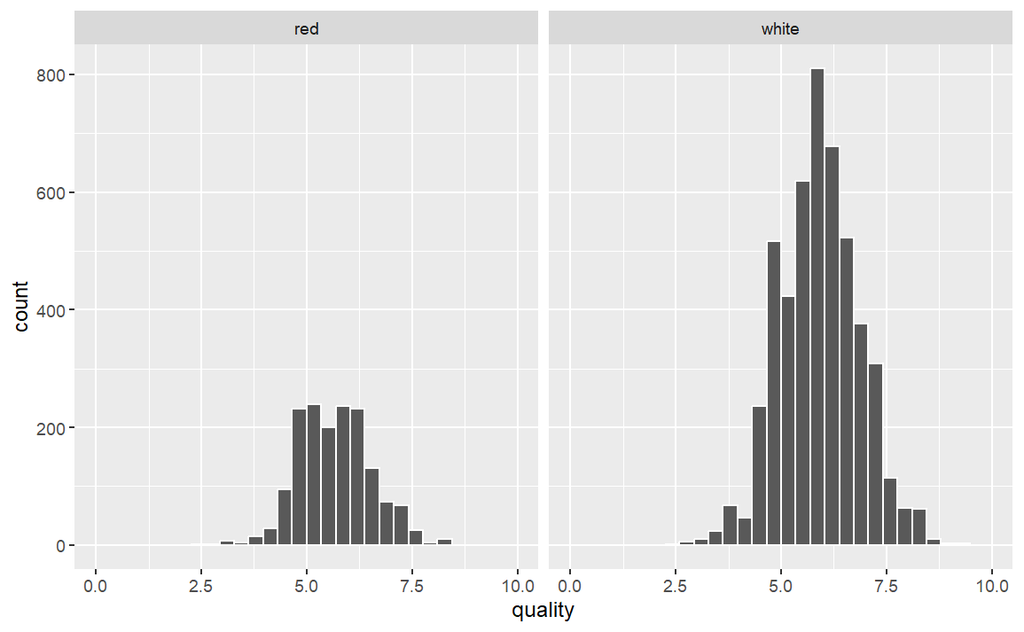

```r
# data for both red and white wines follows a relatively normal distribution
wine_quality_combined %>%
  ggplot() +
  aes(x = quality) +
  geom_histogram(colour = "white", bins = 30) +
  facet_wrap(~ colour) +
  scale_x_continuous(limits = c(0, 10))
```

```r
NA
NA
```

split into numerical and categorical variables:

outcome: quality, categorical: colour, region

numerical: fixed_acidity, volatile_acidity, citric_acid, p_h,

residual_sugar, chlorides, free_sulfur_dioxide, total_sulfur_dioxide, density, sulphates, alcohol

[figure not shown]

```r
#converted categoricals to factors
wine_quality_combined <- wine_quality_combined %>%
  mutate(colour = as.factor(colour),
         region = as.factor(region))





ggpairs(wine_quality_combined, progress =  FALSE)
```

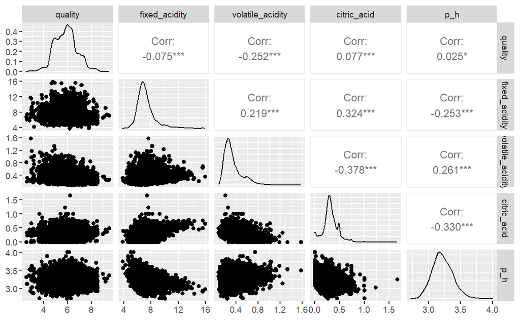

```r
# numerical variables(acidity) correlations with quality
wine_quality_combined %>%
  select(quality, fixed_acidity, volatile_acidity, citric_acid, p_h,) %>%
  ggpairs(progress = FALSE)
```

```r
# none of the variables relating to acidity of the wine have a particularly high crrelation with the wine quality. fixed and volatile acidity seem to cause a reduction in the quality of the wine(weak and relatively weak), citric acid level has a very weak positive correlation, pH also has a very weak/no correlation with the quality of the wine.
```

[figure not shown]

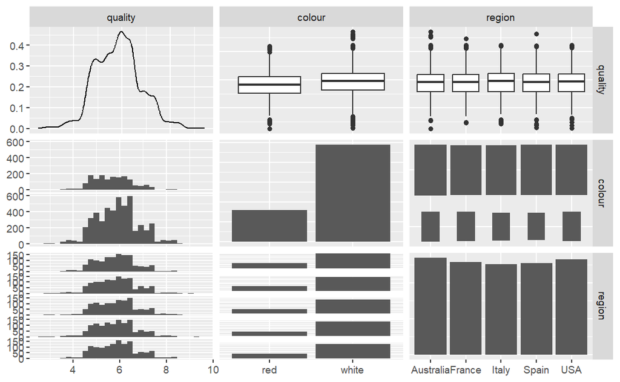

```r
# categorical variables

wine_quality_combined %>%
  select(quality, colour, region) %>%
  ggpairs(progress = FALSE)
```

```r
# from ggpairs plots neither categorical variable, colour or region, appears to have a strong correlation
# witht the quality score of the wine.
```

volatile_acidity density alcohol chlorides

```r
alias(quality ~ ., data = wine_quality_combined)
```

```
Model :
quality ~ colour + fixed_acidity + volatile_acidity + citric_acid +
    residual_sugar + chlorides + free_sulfur_dioxide + total_sulfur_dioxide +
    density + p_h + sulphates + alcohol + region
```

# first predictor

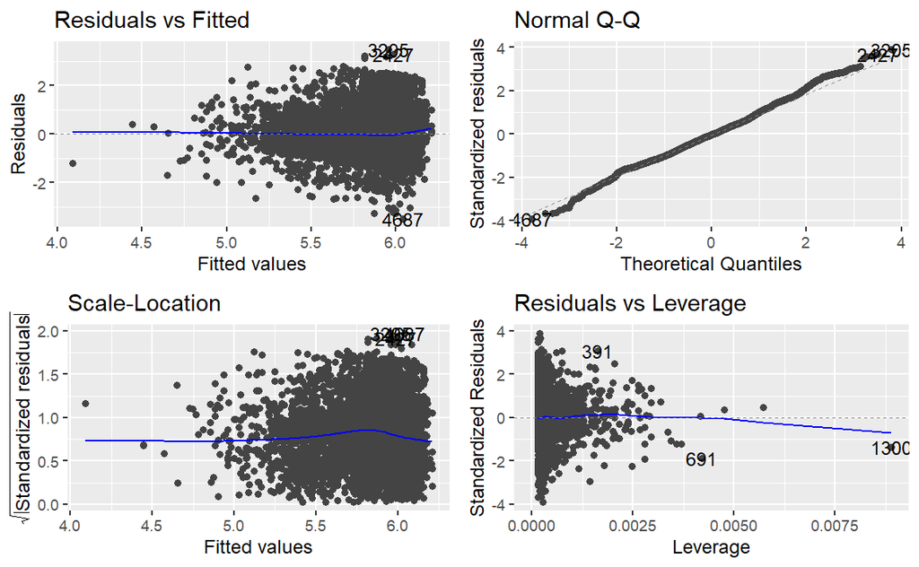

```r
model1a <- lm(quality ~ volatile_acidity, data = wine_quality_combined)
model1b <- lm(quality ~ density, data = wine_quality_combined)
model1c <- lm(quality ~ alcohol, data = wine_quality_combined)
model1d <- lm(quality ~ chlorides, data = wine_quality_combined)

# model 1a - quality ~ volatile acidity
autoplot(model1a)
```

```r
# residuals look ok
# relatively normally distributed
# not too much heteroscedacisity
summary(model1a)
```

```
Call:
lm(formula = quality ~ volatile_acidity, data = wine_quality_combined)

Residuals:
    Min      1Q  Median      3Q     Max
-3.4819 -0.6080 -0.0219  0.5345  3.4830

Coefficients:
                 Estimate Std. Error t value Pr(>|t|)
(Intercept)       6.32492    0.02545  248.48   <2e-16 ***
volatile_acidity -1.41503    0.06744  -20.98   <2e-16 ***
---
Signif. codes:  0 ‘***’ 0.001 ‘**’ 0.01 ‘*’ 0.05 ‘.’ 0.1 ‘ ’ 1

Residual standard error: 0.8948 on 6495 degrees of freedom
Multiple R-squared:  0.06349,   Adjusted R-squared:  0.06334
F-statistic: 440.3 on 1 and 6495 DF,  p-value: < 2.2e-16
```

```r
# r2 value is relatively low, 0.06349, but the effect of volatile_acidity is significant.
```

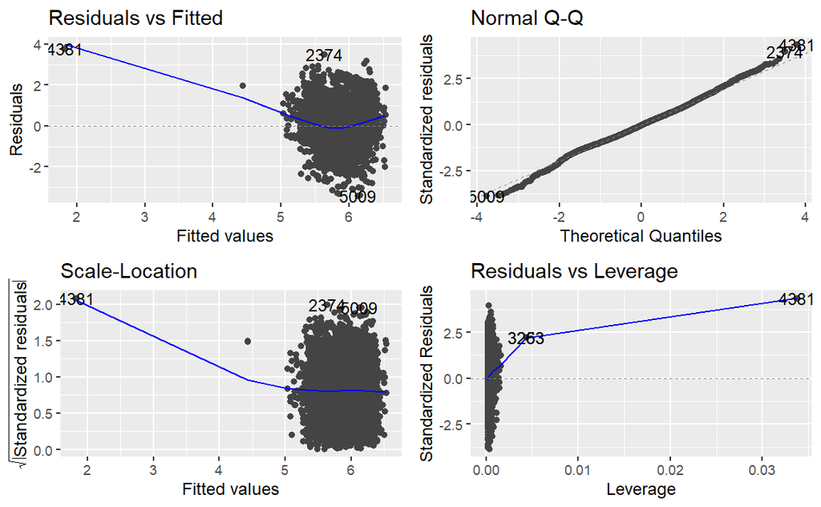

```r
# model 1a - quality ~ volatile acidity
autoplot(model1b)
```

```r
# residuals are not distributed well as outlier appears to alter residuals away from 0
# data does appear to be normally distributed
# large amount of heteroscedasticity observed...
# based upon this would probably discount density as a variable for our linear model.

summary(model1b)
```

```
Call:
lm(formula = quality ~ density, data = wine_quality_combined)

Residuals:
    Min      1Q  Median      3Q     Max
-3.3952 -0.6040 -0.0083  0.5643  3.7937

Coefficients:
            Estimate Std. Error t value Pr(>|t|)
(Intercept)   96.097      3.637   26.42   <2e-16 ***
density      -90.734      3.656  -24.82   <2e-16 ***
---
Signif. codes:  0 ‘***’ 0.001 ‘**’ 0.01 ‘*’ 0.05 ‘.’ 0.1 ‘ ’ 1

Residual standard error: 0.8837 on 6495 degrees of freedom
Multiple R-squared:  0.0866,    Adjusted R-squared:  0.08646
F-statistic: 615.8 on 1 and 6495 DF,  p-value: < 2.2e-16
```

```r
# r2 value, low although density has a signifcant effect on quality...
```

```r
quality ~ alcohol
```

```
quality ~ alcohol
```

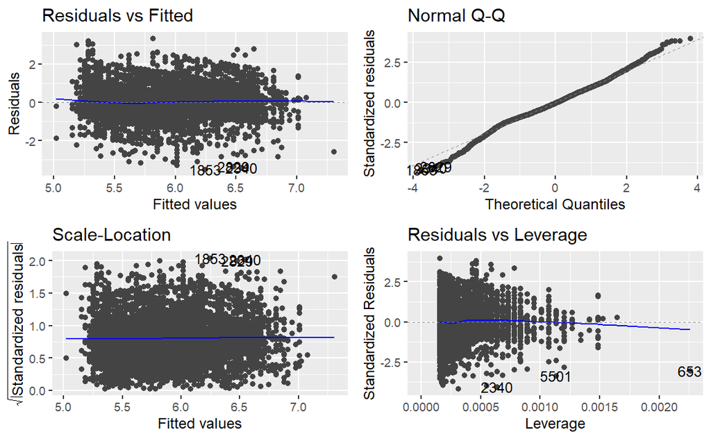

```r
autoplot(model1c)
```

```r
# residuals well distiributed.
# data does appear to be normally distributed
# no heteroscedasicity observed

summary(model1c)
```

```
Call:
lm(formula = quality ~ alcohol, data = wine_quality_combined)

Residuals:
    Min      1Q  Median      3Q     Max
-3.4852 -0.5552 -0.0293  0.5507  3.3362

Coefficients:
            Estimate Std. Error t value Pr(>|t|)
(Intercept) 2.362872   0.091794   25.74   <2e-16 ***
alcohol     0.331822   0.008693   38.17   <2e-16 ***
---
Signif. codes:  0 ‘***’ 0.001 ‘**’ 0.01 ‘*’ 0.05 ‘.’ 0.1 ‘ ’ 1

Residual standard error: 0.8357 on 6495 degrees of freedom
Multiple R-squared:  0.1832,    Adjusted R-squared:  0.1831
F-statistic:  1457 on 1 and 6495 DF,  p-value: < 2.2e-16
```

```r
# r2 value low, 0.1832, (higher than volatility) and effect is significant
```

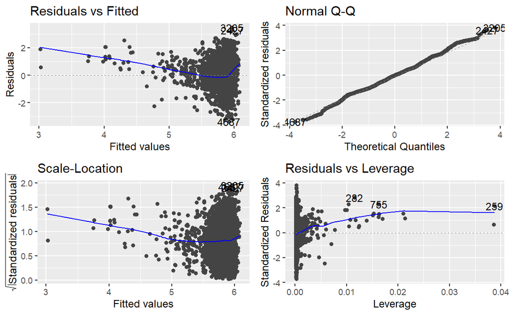

```r
# model1d quality ~ chlorides

autoplot(model1d)
```

```r
# residuals are not distributed well as outlier appears to alter residuals away from 0
# data does appear to be normally distributed
# large amount of heteroscedasticity observed...
# based upon this would probably discount chlorides as a variable for our linear model.

summary(model1d)
```

```
Call:
lm(formula = quality ~ chlorides, data = wine_quality_combined)

Residuals:
    Min      1Q  Median      3Q     Max
-3.3609 -0.6331  0.0073  0.5350  3.4733

Coefficients:
            Estimate Std. Error t value Pr(>|t|)
(Intercept)  6.12974    0.02123  288.69   <2e-16 ***
chlorides   -5.09449    0.32131  -15.86   <2e-16 ***
---
Signif. codes:  0 ‘***’ 0.001 ‘**’ 0.01 ‘*’ 0.05 ‘.’ 0.1 ‘ ’ 1

Residual standard error: 0.9073 on 6495 degrees of freedom
Multiple R-squared:  0.03726,   Adjusted R-squared:  0.03711
F-statistic: 251.4 on 1 and 6495 DF,  p-value: < 2.2e-16
```

```r
# r2 low, effect signifcant but does not meet criteria for linear model
```

best model so far is quality ~ alcohol model1c <- lm(quality ~ alcohol, data = wine_quality_combined)